# Tarea 05

Alejandro Zúñiga Pérez

26/2/2021

# Solución del examen

Se presenta la solución del examen final sobre análisis de datos y visualización de gráficos sobre covid 19. se enlistan algunas de las funciones que permitirán desarrollar uno a uno los procedimientos sugeridos en el enunciado. Se presenta un código fuente que permite la lectura y modificación de un archivo csv. Se modifica a través de la extracción de países en filas y columnas con las fechas para todos los países.

El siguiente es el código mencionado.

```python
import numpy as np
from numpy.core.fromnumeric import transpose
import pandas as pd
import prince
import matplotlib.pyplot as plt
import seaborn as sns
from   sklearn.cluster import KMeans

class ProceseArchivo():
  def CargarArchivo(self,nombrearchivo):
    self.__df=pd.read_csv(nombrearchivo, delimiter=',',decimal=".")
    return True

  def ReducirDataFrame(self,columnas):
    df_reducido=self.__df.drop(  self.__df.columns[columnas],axis=1)
    return df_reducido

  def VisualizarDatos(self):
    print("Contenido de archivo leido")
    print(self.__df.iloc[0:8,0:5])
    print("\nNombres de las columnas (variables)")
    print(self.__df.columns)
    print("\nNombres de los primeros 10 países")
    nombres=self.__df.iloc[:,1]
    print(nombres[0:10])

  def ProcesarDatos(self,NombreArchivo,Indice,ColumnasBorrar):
    if not self.CargarArchivo(NombreArchivo):
      return False
    self.VisualizarDatos()
    df_reducido=self.ReducirDataFrame(ColumnasBorrar)
    df_reducido=df_reducido.set_index(Indice)
    #
    df_reducido=df_reducido.diff(axis=1)
    df_reducido=df_reducido.drop(df_reducido.columns[0],axis=1)
    #
    df_reducido=df_reducido.groupby(df_reducido.index).agg(lambda m:sum(m))
    return df_reducido

Procesar=ProceseArchivo()
xpath="./Data/"
filename_eval = 'time_series_covid19_confirmed_global.csv'
indice="Country/Region"
ColumnsToDelete=[0]+ list(range(2,4))    # Se eliminarán en todos los archivos las columnas 0,2,3
DF=Procesar.ProcesarDatos(xpath+filename_eval,indice,ColumnsToDelete)
```

```
## Contenido de archivo leido
##   Province/State       Country/Region       Lat       Long  1/22/20
## 0            NaN          Afghanistan  33.93911  67.709953        0
## 1            NaN              Albania  41.15330  20.168300        0
## 2            NaN              Algeria  28.03390   1.659600        0
## 3            NaN              Andorra  42.50630   1.521800        0
## 4            NaN               Angola -11.20270  17.873900        0
## 5            NaN  Antigua and Barbuda  17.06080 -61.796400        0
## 6            NaN            Argentina -38.41610 -63.616700        0
## 7            NaN              Armenia  40.06910  45.038200        0
##
## Nombres de las columnas (variables)
## Index(['Province/State', 'Country/Region', 'Lat', 'Long', '1/22/20', '1/23/20',
##        '1/24/20', '1/25/20', '1/26/20', '1/27/20',
##        ...
##        '2/20/21', '2/21/21', '2/22/21', '2/23/21', '2/24/21', '2/25/21',
##        '2/26/21', '2/27/21', '2/28/21', '3/1/21'],
##       dtype='object', length=409)
##
## Nombres de los primeros 10 países
## 0            Afghanistan
## 1                Albania
## 2                Algeria
## 3                Andorra
## 4                 Angola
## 5    Antigua and Barbuda
## 6              Argentina
## 7                Armenia
## 8              Australia
## 9              Australia
## Name: Country/Region, dtype: object
```

Ahora se muestra el archivo reducido para proceder con la solución del examen.

```python
print('Archivo reducido para resolver el examen: ')
```

```
## Archivo reducido para resolver el examen:
```

```python
print(DF)
```

```
##                     1/23/20  1/24/20  1/25/20  ...  2/27/21  2/28/21  3/1/21
## Country/Region                                 ...
## Afghanistan             0.0      0.0      0.0  ...     11.0      7.0    19.0
## Albania                 0.0      0.0      0.0  ...    986.0    952.0   764.0
## Algeria                 0.0      0.0      0.0  ...    155.0    132.0   163.0
## Andorra                 0.0      0.0      0.0  ...     27.0     17.0    23.0
## Angola                  0.0      0.0      0.0  ...     23.0     25.0    47.0
## ...                     ...      ...      ...  ...      ...      ...     ...
## Vietnam                 2.0      0.0      0.0  ...      6.0     16.0     0.0
## West Bank and Gaza      0.0      0.0      0.0  ...   1061.0   1703.0  1724.0
## Yemen                   0.0      0.0      0.0  ...      2.0     16.0    25.0
## Zambia                  0.0      0.0      0.0  ...    563.0    332.0   468.0
## Zimbabwe                0.0      0.0      0.0  ...     14.0     31.0    26.0
##
## [192 rows x 404 columns]
```

Se procede con la solución del examen.

## Procedimiento 1

Se tiene primeramente una función que recoge los países asignados previamente en el enunciado. Se retorna este dataframe modificado y se imprime en pantalla.

```python
def split_data(df):
    countries = ['Costa Rica', 'Guatemala', 'Honduras', 'El Salvador', 'Panama', 'Mexico', 'Belize', 'Canada', 'Cuba', 'Haiti', 'Trinidad and Tobago']
    df_dot = df.loc[countries]
    return df_dot
print(split_data(DF))
```

```
##                      1/23/20  1/24/20  1/25/20  ...  2/27/21  2/28/21  3/1/21
## Country/Region                                  ...
## Costa Rica               0.0      0.0      0.0  ...      0.0      0.0   745.0
## Guatemala                0.0      0.0      0.0  ...    521.0    207.0   111.0
## Honduras                 0.0      0.0      0.0  ...    843.0    550.0   681.0
## El Salvador              0.0      0.0      0.0  ...      0.0      0.0     0.0
## Panama                   0.0      0.0      0.0  ...    664.0    470.0   505.0
## Mexico                   0.0      0.0      0.0  ...   7246.0   2810.0  2343.0
## Belize                   0.0      0.0      0.0  ...      0.0      0.0    20.0
## Canada                   0.0      0.0      0.0  ...   2680.0   2347.0  3694.0
## Cuba                     0.0      0.0      0.0  ...    720.0    618.0   811.0
## Haiti                    0.0      0.0      0.0  ...     78.0      0.0    18.0
## Trinidad and Tobago      0.0      0.0      0.0  ...      1.0      8.0     3.0
##
## [11 rows x 404 columns]
```

Seguidamente, se procede a transponer el dataframe y retornarlo y se imprime en pantalla para mostrar funcionalidad.

```python
def transpose_df(dataf):
    df = split_data(dataf)
    return df.T
dat_tr= transpose_df(DF)
print(dat_tr)
```

```
## Country/Region  Costa Rica  Guatemala  ...  Haiti  Trinidad and Tobago
## 1/23/20                0.0        0.0  ...    0.0                  0.0
## 1/24/20                0.0        0.0  ...    0.0                  0.0
## 1/25/20                0.0        0.0  ...    0.0                  0.0
## 1/26/20                0.0        0.0  ...    0.0                  0.0
## 1/27/20                0.0        0.0  ...    0.0                  0.0
## ...                    ...        ...  ...    ...                  ...
## 2/25/21              418.0      378.0  ...    0.0                  7.0
## 2/26/21              427.0      672.0  ...    0.0                  7.0
## 2/27/21                0.0      521.0  ...   78.0                  1.0
## 2/28/21                0.0      207.0  ...    0.0                  8.0
## 3/1/21               745.0      111.0  ...   18.0                  3.0
##
## [404 rows x 11 columns]
```

## Procedimiento 2

Se utiliza la exploración de clusterización correspondiente al agrupamiento de tres conjuntos de datos. Se presenta la función que arroja estos resultados consistiendo esencialmente en tres gráficas de barras que refieren a cada agrupación respectiva.

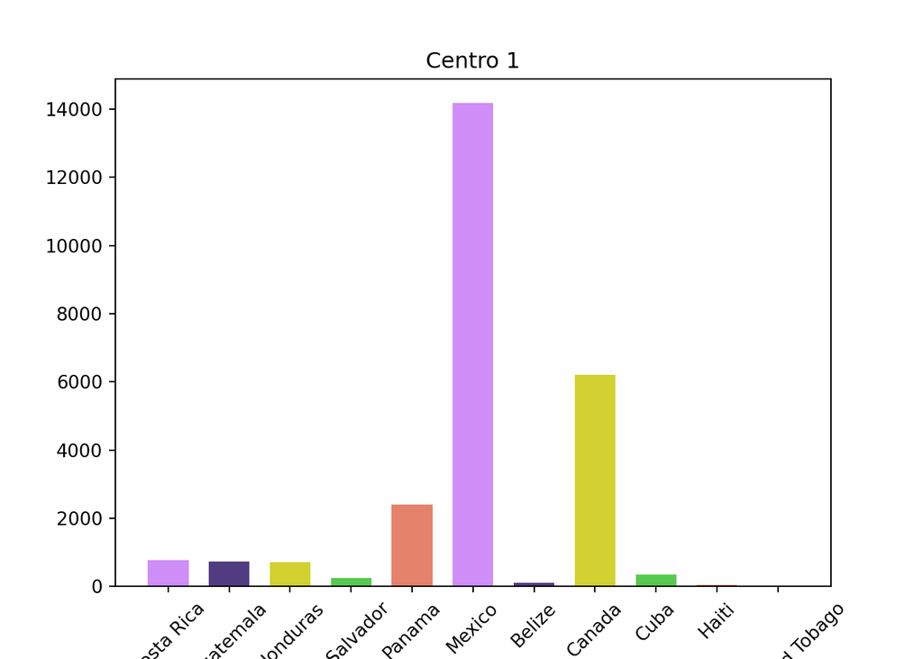

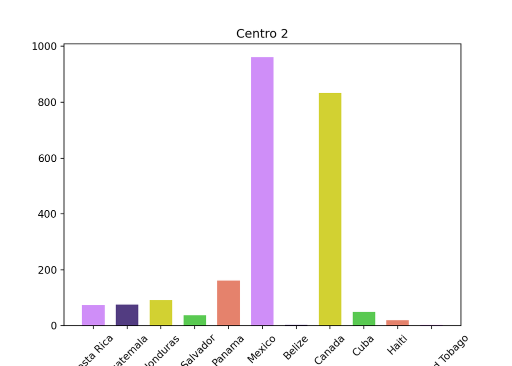

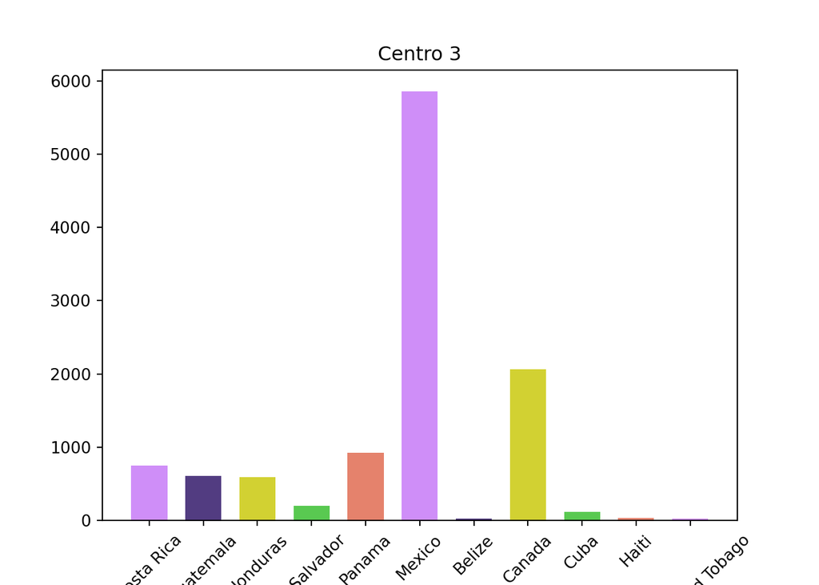

```python
def k_means(dataframe):
    kmeans = KMeans(n_clusters=3)
    kmeans.fit(dataframe)
    centros = np.array(kmeans.cluster_centers_)
    vert = centros[:1,:]
    y  = vert.tolist()[0]
    N = len(y)
    x = range(N)
    width = 1/1.5
    colores = ['#CF8EF8', '#523C81', '#D2D132', '#59C951', '#E5826C']
    null=plt.bar(x, y, width, color=colores)
    null=plt.xticks(range(dataframe.shape[1]), dataframe.columns, rotation=45, fontsize=10)
    plt.title("Centro 1")
    plt.show()
    plt.close()

    #centro 2
    vert1 = centros[1:2,:]
    y1  = vert1.tolist()[0]
    N1 = len(y1)
    x1 = range(N1)
    width = 1/1.5
    colores = ['#CF8EF8', '#523C81', '#D2D132', '#59C951', '#E5826C']
    null=plt.bar(x1, y1, width, color=colores)
    null=plt.xticks(range(dataframe.shape[1]), dataframe.columns, rotation=45, fontsize=10)
    plt.title("Centro 2")
    plt.show()
    plt.close()

    # centro 3
    vert2 = centros[2:3,:]
    y2  = vert2.tolist()[0]
    N2 = len(y2)
    x2 = range(N2)
    width = 1/1.5
    colores = ['#CF8EF8', '#523C81', '#D2D132', '#59C951', '#E5826C']
    null=plt.bar(x2, y2, width, color=colores)
    null=plt.xticks(range(dataframe.shape[1]), dataframe.columns, rotation=45, fontsize=10)
    plt.title("Centro 3")
    plt.show()
    plt.close()

k_means(dat_tr)
```

Lo que se concluye de este análisis es que el cluster hecho a partir de kmedias toma tres promedios aleatorios que definen la proporción relativa que en este caso se trata de poblaciones o conjuntos de datos correspondiente a casos confirmados. Es un hecho que la población de México se podrá ver mucho mayor que la del resto de centroamérica por la mayoría de población de dicho país.

Ahora se procede a modificar de una forma adicional el dataframe en cuestión. Se añaden columnas respectivas al mes y al año para representar los casos confirmados por mes y año de forma enumerada.

```python
def groups(dataframe):
    '''Se agrupa por mes y año el dataframe
    Se retorna el valor medio diario de casos
    para cada combinacion de mes y annio'''

    tdf = transpose_df(dataframe)
    months = pd.DatetimeIndex(tdf.index).month
    tdm =tdf.assign(mes_x = months)
    annos = pd.DatetimeIndex(tdf.index).year
    tdm = tdm.assign(year_x = annos)
    covid = tdm.groupby(['mes_x','year_x']).mean()
    return covid
```

Con el dataframe modificado se pretende ahora clusterizar nuevamente para volver a apreciar los resultados finales.

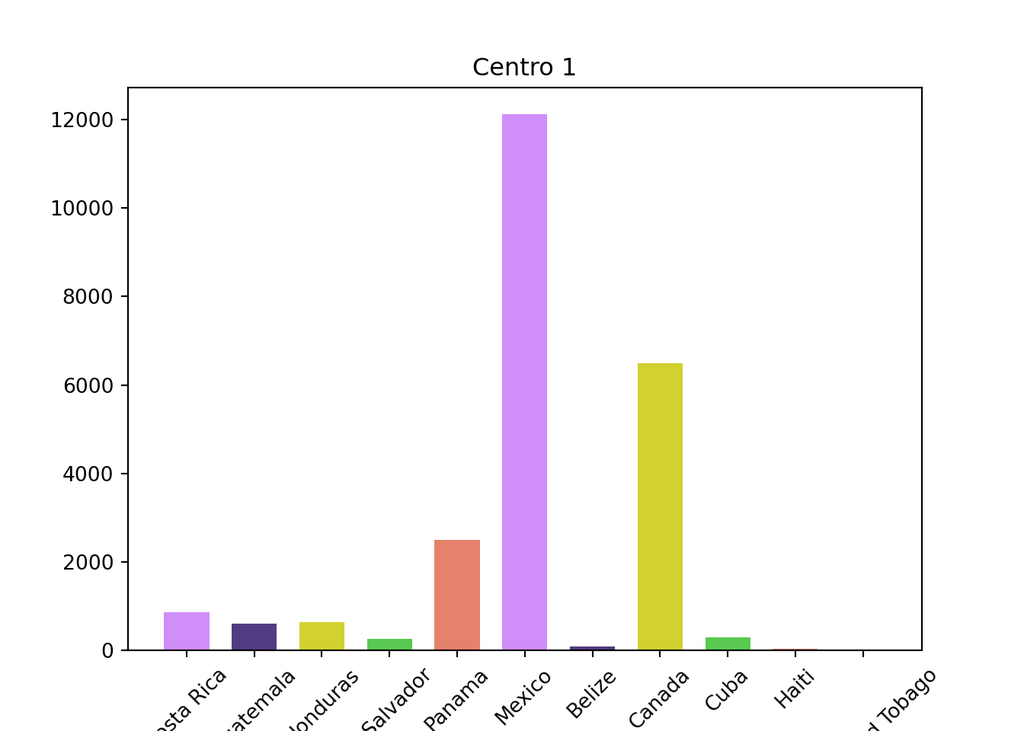

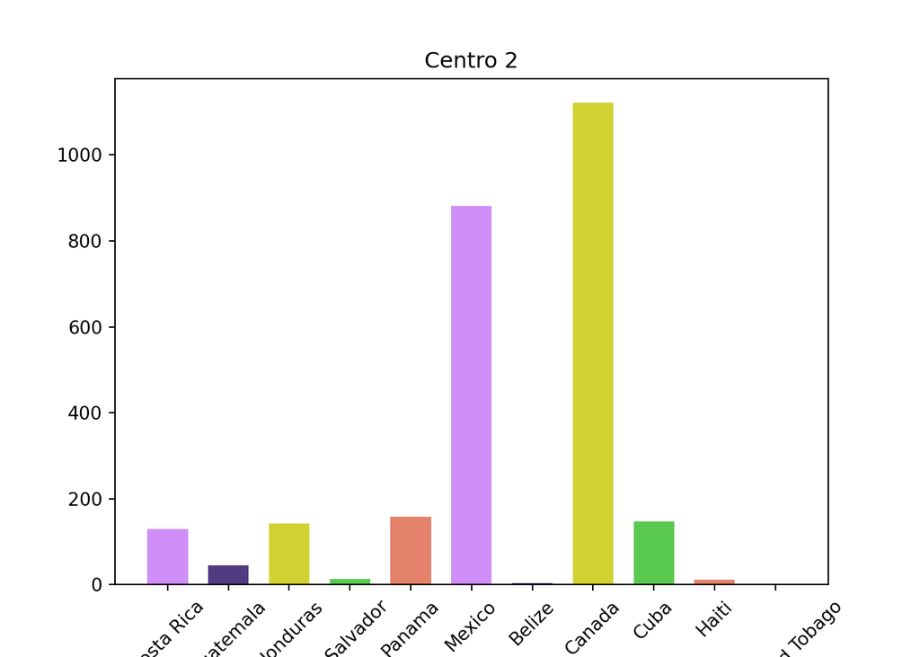

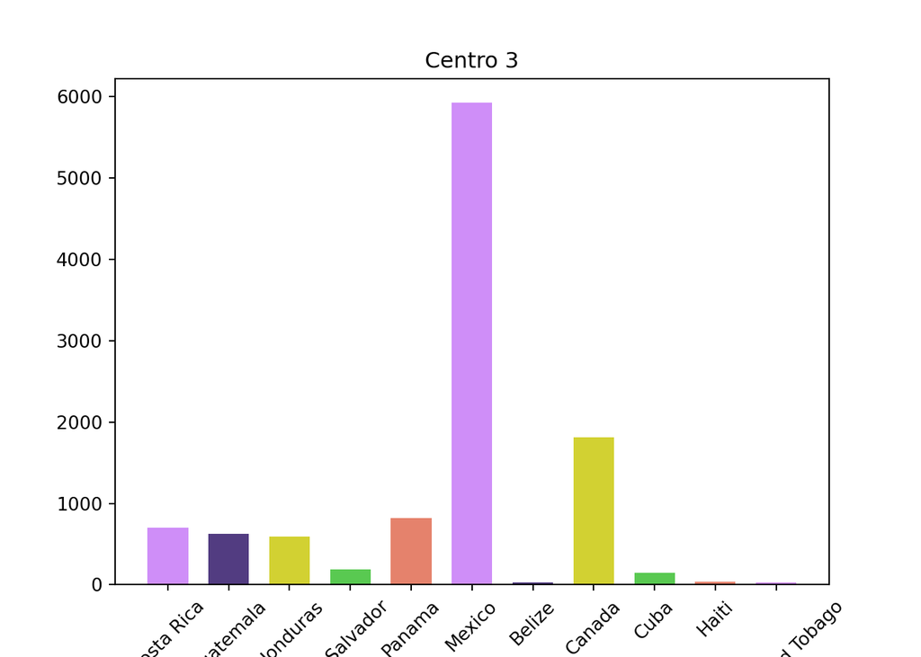

```python
new_DF = groups(DF)
k_means(new_DF)
```

Dentro de este análisis se evalúa que igualmente, la proporción de poblaciones con casos confirmados pretende ser mayor en los países con mayor población, siendo esta una apreciación poco contundente de los clusteres realizados. De esta manera se puede adjuntar más épocas de ajuste para el método de clusterización y quizá de esta forma se pueda representar ya no en términos de poblaciones relativas, sino analizar relaciones en términos de los clusteres evaluados.

## Procedimiento 4

En esta última sección se grafica a través de cuadro de calor y box plot los resultados obtenidos. Se crean dos funciones correspondientes a graficar cada uno de estos elementos.

```python
def plot_heatmap(dataframe):
    sum_casos = dataframe.apply(lambda x : x/max(x))
    heat = sns.heatmap(sum_casos.corr(),
    mask=np.zeros_like(sum_casos.corr()),
    cmap=sns.diverging_palette(220, 10, as_cmap=True))
    plt.show()
    plt.close()

def box_plot(dataframe):
    box = dataframe.boxplot(column=['Costa Rica', 'Guatemala', 'Honduras', 'El Salvador', 'Panama', 'Mexico', 'Belize', 'Canada', 'Cuba', 'Haiti', 'Trinidad and Tobago'])
    plt.xticks(rotation=45)
    plt.show()
    plt.close()
```

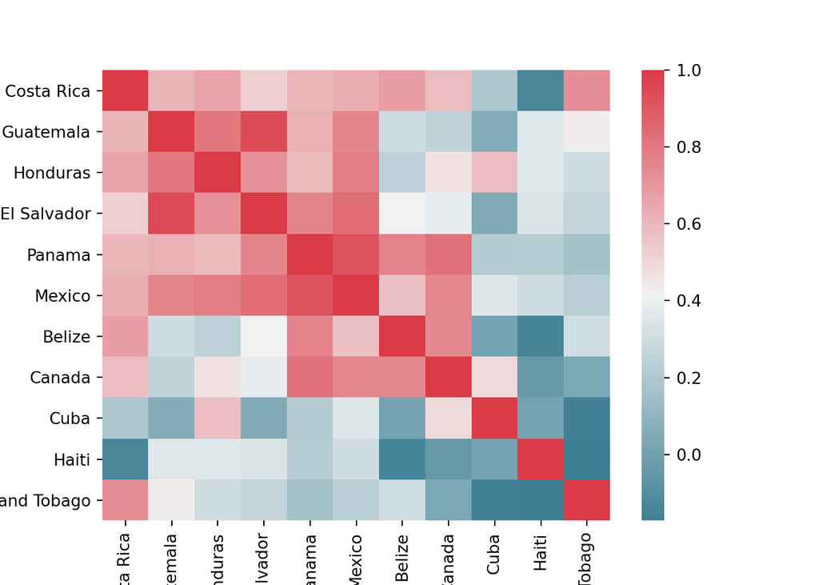

```python
plot_heatmap(new_DF)
```

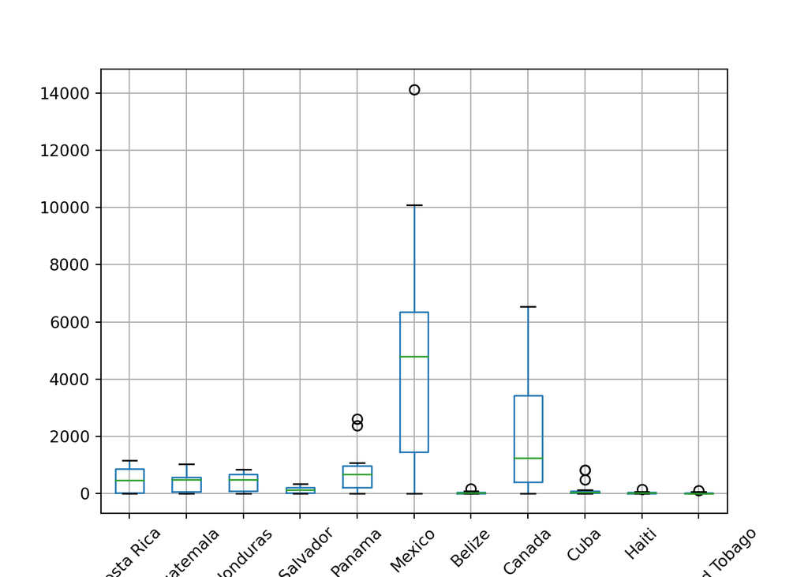

```python
box_plot(new_DF)
```

Finalmente, del gráfico de cajas y bigotes se aprecia de igual manera una distribución mayor para México y Canadá, y por supuesto los demás países resultaron con una menor distribución, tal y como lo mostró el método de K medias.